# Optimizing Whiff Probability for Pitcher X

Will Moscato

2022-07-29

# Outline

- Optimizing overall pitch usage.
- Optimizing movement profiles of each pitch.
- Optimizing location for each pitch type.
- Optimizing location and pitch usage in each type of count.

# Breakdown of pitches thrown by Pitch Type

## Total

| Pitch Usage Table PitchType | Pitch Usage Table total | Pitch Usage Table % of Usage |
| --- | --- | --- |
| FASTBALL | 1087 | 40.02209 |
| CUTTER | 789 | 29.05007 |
| CHANGEUP | 422 | 15.53756 |
| CURVEBALL | 418 | 15.39028 |

## Vs Left

| Pitch Usage Vs Left Table PitchType | Pitch Usage Vs Left Table total | Pitch Usage Vs Left Table % of Usage |
| --- | --- | --- |
| FASTBALL | 416 | 34.46562 |
| CHANGEUP | 339 | 28.08616 |
| CUTTER | 299 | 24.77216 |
| CURVEBALL | 153 | 12.67606 |

## Vs Right

| Pitch Usage Vs Right Table PitchType | Pitch Usage Vs Right Table total | Pitch Usage Vs Right Table % of Usage |
| --- | --- | --- |
| FASTBALL | 671 | 44.466534 |
| CUTTER | 490 | 32.471836 |
| CURVEBALL | 265 | 17.561299 |
| CHANGEUP | 83 | 5.500331 |

# Pitches by Whiff Probalbility

## Vs Left

| Whiff Probabilites by Pitch Type Vs Left PitchType | Whiff Probabilites by Pitch Type Vs Left Minimun Whiff Probability | Whiff Probabilites by Pitch Type Vs Left Maximum Whiff Probability | Whiff Probabilites by Pitch Type Vs Left Average whiff Probability |
| --- | --- | --- | --- |
| CHANGEUP | 0.0004328 | 0.4642051 | 0.1478895 |
| CURVEBALL | 0.0001035 | 0.3804127 | 0.0922867 |
| CUTTER | 0.0007961 | 0.5077831 | 0.1249060 |
| FASTBALL | 0.0000240 | 0.3233565 | 0.0691044 |

## Vs Right

| Whiff Probabilities by Pitch Type Vs Right PitchType | Whiff Probabilities by Pitch Type Vs Right Minimun Whiff Probability | Whiff Probabilities by Pitch Type Vs Right Maximum Whiff Probability | Whiff Probabilities by Pitch Type Vs Right Average whiff Probability |
| --- | --- | --- | --- |
| CHANGEUP | 0.0019991 | 0.4788090 | 0.1717387 |
| CURVEBALL | 0.0001618 | 0.3685120 | 0.1207239 |
| CUTTER | 0.0019929 | 0.4149693 | 0.1471326 |
| FASTBALL | 0.0004955 | 0.3820167 | 0.0970859 |

## Takeaways from this section

The big takeaway is that the changeup needs to be thrown more to righties.

# Movement profiles

## Vs Left

### All pitches

| Pitch Profiles by Pitch Type Pitch Type | Pitch Profiles by Pitch Type Average Velocity | Pitch Profiles by Pitch Type Average Induced Vertical Break | Pitch Profiles by Pitch Type Average Horizontal Break | Pitch Profiles by Pitch Type Average Release Height | Pitch Profiles by Pitch Type Average Release Side | Pitch Profiles by Pitch Type Average Extension | Pitch Profiles by Pitch Type Average Spin Rate | Pitch Profiles by Pitch Type Average Spin Axis |
| --- | --- | --- | --- | --- | --- | --- | --- | --- |
| CHANGEUP | 82.58079 | 9.594375 | 12.191757 | 6.718637 | 0.8663193 | 5.959408 | 1324.306 | 217.73124 |
| CURVEBALL | 76.63333 | -13.241289 | -7.769717 | 6.895135 | 0.7134182 | 5.900976 | 2696.759 | 24.46737 |
| CUTTER | 89.27395 | 7.909595 | -4.712268 | 6.876399 | 0.8542778 | 5.977810 | 2296.332 | 170.72836 |
| FASTBALL | 92.73236 | 18.433175 | 2.195867 | 6.897988 | 0.8527365 | 5.969803 | 2114.302 | 197.24460 |

### Best Whiff Probabilties by Pitch Type

| Best Pitch Profiles by Pitch Type Pitch Type | Best Pitch Profiles by Pitch Type Average Velocity | Best Pitch Profiles by Pitch Type Average Induced Vertical Break | Best Pitch Profiles by Pitch Type Average Horizontal Break | Best Pitch Profiles by Pitch Type Average Release Height | Best Pitch Profiles by Pitch Type Average Release Side | Best Pitch Profiles by Pitch Type Average Extension | Best Pitch Profiles by Pitch Type Average Spin Rate | Best Pitch Profiles by Pitch Type Average Spin Axis |
| --- | --- | --- | --- | --- | --- | --- | --- | --- |
| CHANGEUP | 82.83131 | 6.754483 | 12.087501 | 6.724340 | 0.8420155 | 5.897846 | 1318.290 | 218.27398 |
| CURVEBALL | 77.90869 | -12.730392 | -8.450697 | 6.890107 | 0.6289812 | 5.943250 | 2740.174 | 24.66522 |
| CUTTER | 89.77809 | 7.502558 | -4.861665 | 6.851628 | 0.8138759 | 6.134616 | 2298.654 | 172.48830 |
| FASTBALL | 92.97178 | 18.777285 | 1.474512 | 6.890735 | 0.7990840 | 5.931874 | 2147.305 | 196.39412 |

### Worst Whiff Probabilities by Pitch Type

| Worst Pitch Profiles by Pitch Type Pitch Type | Worst Pitch Profiles by Pitch Type Average Velocity | Worst Pitch Profiles by Pitch Type Average Induced Vertical Break | Worst Pitch Profiles by Pitch Type Average Horizontal Break | Worst Pitch Profiles by Pitch Type Average Release Height | Worst Pitch Profiles by Pitch Type Average Release Side | Worst Pitch Profiles by Pitch Type Average Extension | Worst Pitch Profiles by Pitch Type Average Spin Rate | Worst Pitch Profiles by Pitch Type Average Spin Axis |
| --- | --- | --- | --- | --- | --- | --- | --- | --- |
| CHANGEUP | 81.74264 | 9.258275 | 11.113257 | 6.768038 | 0.8188862 | 5.921700 | 1319.864 | 218.38878 |
| CURVEBALL | 76.55604 | -12.865961 | -8.661057 | 6.927434 | 0.6692168 | 5.936296 | 2715.611 | 24.59411 |
| CUTTER | 90.20350 | 9.401698 | -4.010338 | 6.871270 | 0.8732283 | 6.031023 | 2286.681 | 177.09622 |
| FASTBALL | 92.53811 | 17.878388 | 1.484524 | 6.893050 | 0.7112976 | 5.995566 | 2076.815 | 196.51821 |

### Closer Look at Best Changeups

| Best Changeups Vs Left Pitch Type | Best Changeups Vs Left Velocity | Best Changeups Vs Left Induced Vertical Break | Best Changeups Vs Left Horizontal Break | Best Changeups Vs Left Spin Rate | Best Changeups Vs Left Spin Axis | Best Changeups Vs Left Whiff Probability |
| --- | --- | --- | --- | --- | --- | --- |
| CHANGEUP | 83.68232 | 5.016430 | 10.19773 | 1391.781 | 222.4788 | 0.4642051 |
| CHANGEUP | 82.47786 | 5.040734 | 13.79475 | 1238.108 | 222.0060 | 0.4387583 |
| CHANGEUP | 80.78189 | 3.294136 | 14.48287 | 1262.100 | 224.4260 | 0.4094998 |
| CHANGEUP | 81.87243 | 6.498928 | 11.64570 | 1285.229 | 213.6384 | 0.3962128 |
| CHANGEUP | 85.59802 | 6.218484 | 7.85757 | 1460.647 | 210.8095 | 0.3879089 |
| CHANGEUP | 82.62807 | 9.091421 | 11.77007 | 1386.602 | 220.7870 | 0.3718592 |
| CHANGEUP | 83.61014 | 7.351449 | 13.19746 | 1274.360 | 216.5208 | 0.3609606 |
| CHANGEUP | 84.13604 | 10.018172 | 10.82327 | 1259.379 | 215.1741 | 0.3603144 |
| CHANGEUP | 81.92071 | 9.225714 | 14.06283 | 1378.548 | 217.7777 | 0.3509780 |
| CHANGEUP | 81.60562 | 5.789361 | 13.04277 | 1246.147 | 219.1213 | 0.3492793 |

### Closer Look at Worst Changeups

| Worst Changeups Vs Left Pitch Type | Worst Changeups Vs Left Velocity | Worst Changeups Vs Left Induced Vertical Break | Worst Changeups Vs Left Horizontal Break | Worst Changeups Vs Left Spin Rate | Worst Changeups Vs Left Spin Axis | Worst Changeups Vs Left Whiff Probability |
| --- | --- | --- | --- | --- | --- | --- |
| CHANGEUP | 82.15607 | 10.121734 | 9.849166 | 1399.724 | 216.1271 | 0.0703081 |
| CHANGEUP | 82.47224 | 9.354640 | 11.675639 | 1459.440 | 217.7586 | 0.0856296 |
| CHANGEUP | 82.12239 | 7.370033 | 12.424531 | 1246.278 | 211.7380 | 0.0864346 |
| CHANGEUP | 81.58536 | 10.042692 | 14.025578 | 1235.480 | 219.8115 | 0.0893290 |
| CHANGEUP | 81.86103 | 7.453824 | 11.658656 | 1327.608 | 224.6151 | 0.0904011 |
| CHANGEUP | 80.80639 | 8.740800 | 11.569223 | 1224.438 | 215.0350 | 0.0921637 |
| CHANGEUP | 82.09798 | 9.414299 | 8.410356 | 1415.818 | 213.4574 | 0.0937586 |
| CHANGEUP | 81.34315 | 8.350818 | 10.561701 | 1318.842 | 224.5389 | 0.0942847 |
| CHANGEUP | 82.03779 | 10.878533 | 12.147104 | 1316.017 | 219.3680 | 0.0945431 |
| CHANGEUP | 80.94394 | 10.855373 | 8.810615 | 1254.998 | 221.4382 | 0.0949953 |

## Vs Right

### All pitches

| Pitch Profiles by Pitch Type Pitch Type | Pitch Profiles by Pitch Type Average Velocity | Pitch Profiles by Pitch Type Average Induced Vertical Break | Pitch Profiles by Pitch Type Average Horizontal Break | Pitch Profiles by Pitch Type Average Release Height | Pitch Profiles by Pitch Type Average Release Side | Pitch Profiles by Pitch Type Average Extension | Pitch Profiles by Pitch Type Average Spin Rate | Pitch Profiles by Pitch Type Average Spin Axis |
| --- | --- | --- | --- | --- | --- | --- | --- | --- |
| CHANGEUP | 83.30785 | 9.640164 | 12.375988 | 6.708812 | 0.6883083 | 6.059394 | 1337.262 | 217.69275 |
| CURVEBALL | 77.55062 | -12.809821 | -7.999745 | 6.901032 | 0.6366196 | 5.934325 | 2716.812 | 24.52097 |
| CUTTER | 89.02865 | 7.113560 | -5.121137 | 6.892764 | 0.6494684 | 5.979117 | 2306.659 | 167.09638 |
| FASTBALL | 92.77672 | 18.381337 | 1.917195 | 6.893305 | 0.6904832 | 6.022415 | 2105.086 | 196.04318 |

### Best Whiff Probabilties by Pitch Type

| Best Pitch Profiles by Pitch Type Pitch Type | Best Pitch Profiles by Pitch Type Average Velocity | Best Pitch Profiles by Pitch Type Average Induced Vertical Break | Best Pitch Profiles by Pitch Type Average Horizontal Break | Best Pitch Profiles by Pitch Type Average Release Height | Best Pitch Profiles by Pitch Type Average Release Side | Best Pitch Profiles by Pitch Type Average Extension | Best Pitch Profiles by Pitch Type Average Spin Rate | Best Pitch Profiles by Pitch Type Average Spin Axis |
| --- | --- | --- | --- | --- | --- | --- | --- | --- |
| CHANGEUP | 83.46845 | 8.902534 | 12.478859 | 6.699660 | 0.6139552 | 6.053541 | 1333.486 | 217.78915 |
| CURVEBALL | 77.06888 | -13.143665 | -7.774277 | 6.879274 | 0.7796106 | 5.995212 | 2716.878 | 23.96439 |
| CUTTER | 88.80381 | 5.260254 | -5.917273 | 6.884895 | 0.6415536 | 5.924507 | 2303.557 | 164.84595 |
| FASTBALL | 93.07805 | 18.656395 | 1.710489 | 6.941578 | 0.7270958 | 5.991630 | 2114.479 | 196.32463 |

### Worst Whiff Probabilties by Pitch Type

| Worst Pitch Profiles by Pitch Type Pitch Type | Worst Pitch Profiles by Pitch Type Average Velocity | Worst Pitch Profiles by Pitch Type Average Induced Vertical Break | Worst Pitch Profiles by Pitch Type Average Horizontal Break | Worst Pitch Profiles by Pitch Type Average Release Height | Worst Pitch Profiles by Pitch Type Average Release Side | Worst Pitch Profiles by Pitch Type Average Extension | Worst Pitch Profiles by Pitch Type Average Spin Rate | Worst Pitch Profiles by Pitch Type Average Spin Axis |
| --- | --- | --- | --- | --- | --- | --- | --- | --- |
| CHANGEUP | 82.57362 | 8.152958 | 12.857287 | 6.705629 | 0.6968874 | 6.055147 | 1289.906 | 218.20707 |
| CURVEBALL | 77.66700 | -12.778142 | -8.021556 | 6.905104 | 0.6453668 | 6.025852 | 2721.521 | 25.41385 |
| CUTTER | 89.08975 | 8.286464 | -4.114315 | 6.894936 | 0.7657831 | 5.985232 | 2259.543 | 172.07437 |
| FASTBALL | 92.28518 | 17.904389 | 3.057209 | 6.840957 | 0.6948035 | 6.080866 | 2119.728 | 195.31872 |

### Closer Look into Best Cutters

[output not shown]

### Closer Look into Worst Cutters

[output not shown]

# By Location

## Fastballs

### Vs Left

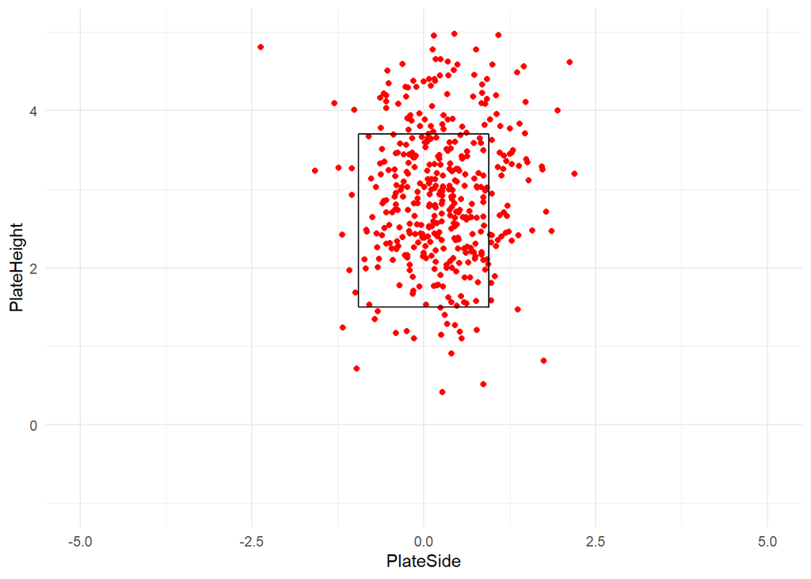

#### Best Whiff Probabilities

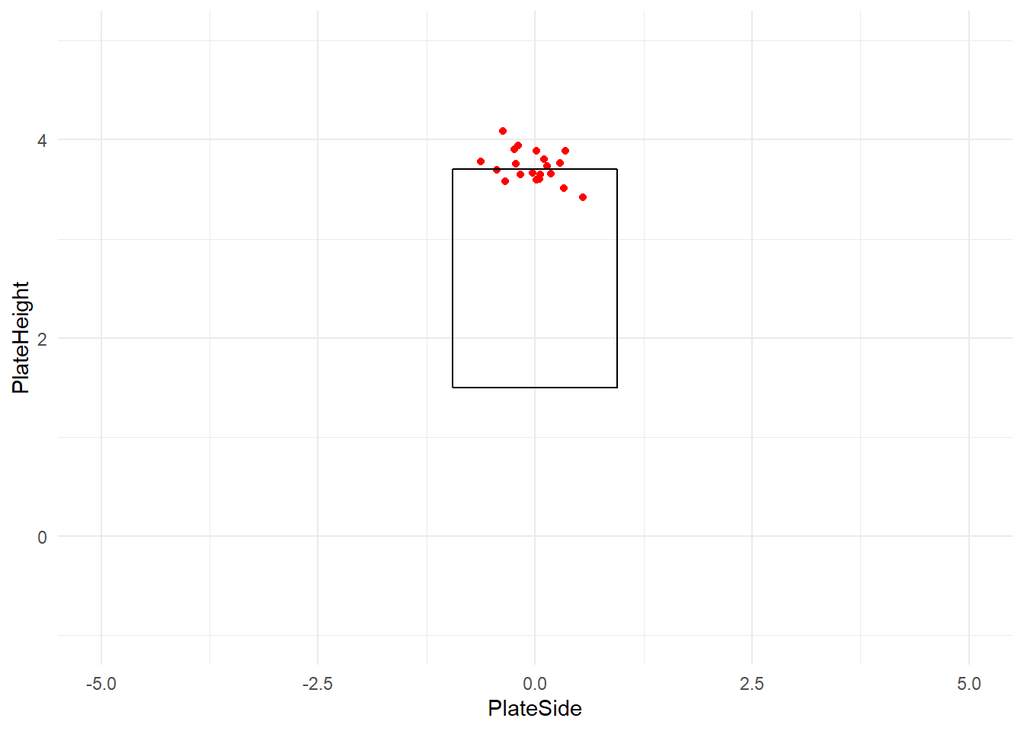

#### Worst Whiff Probabilities

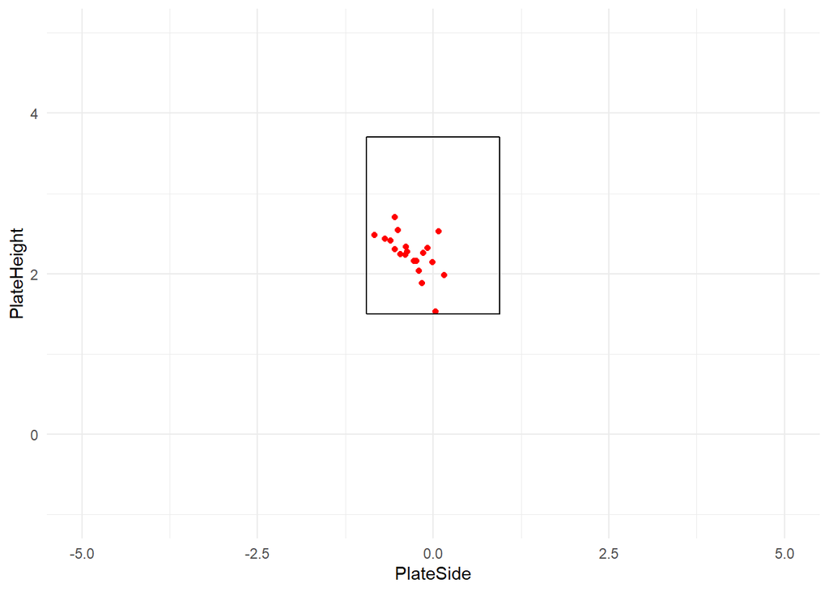

### Vs Right

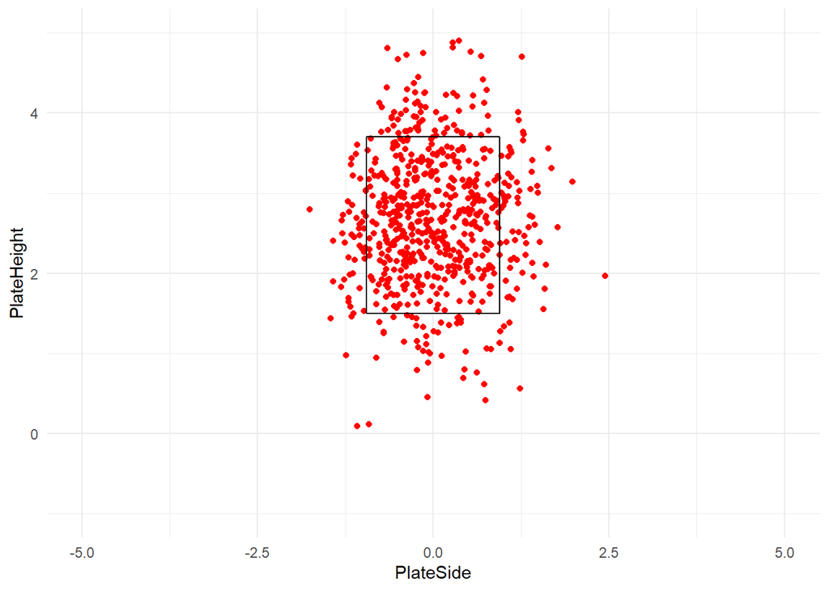

#### Best Whiff Probabilities

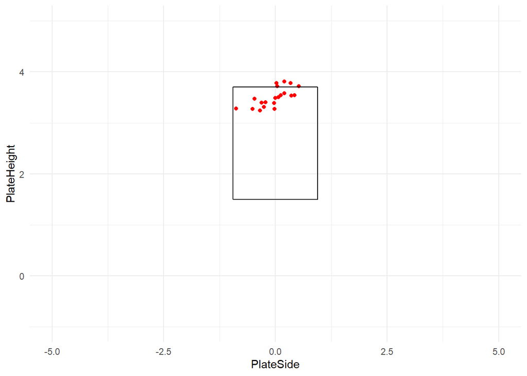

#### Worst Whiff Probabilities

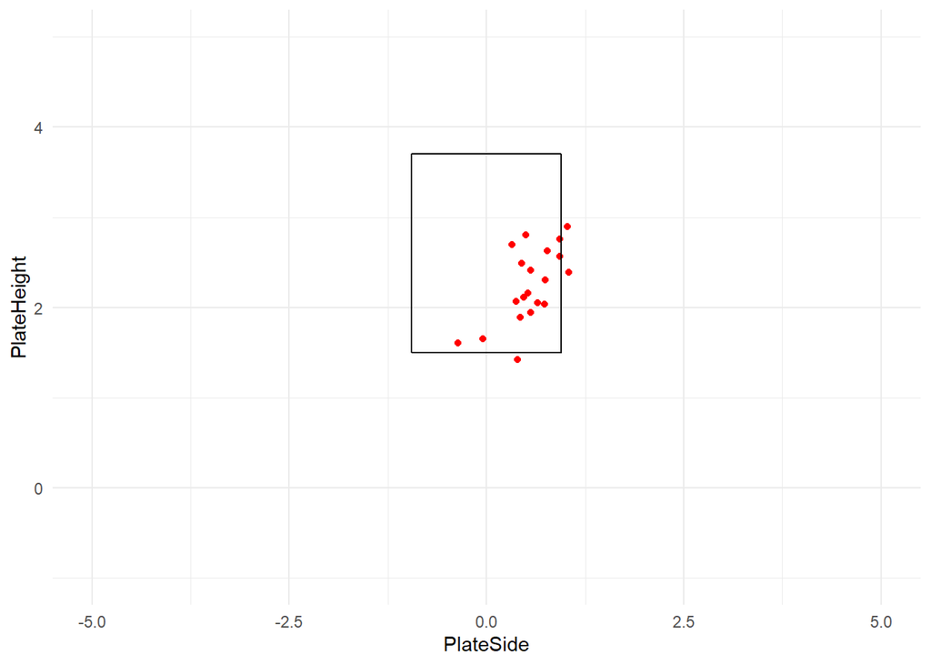

## Cutters

### Vs Left

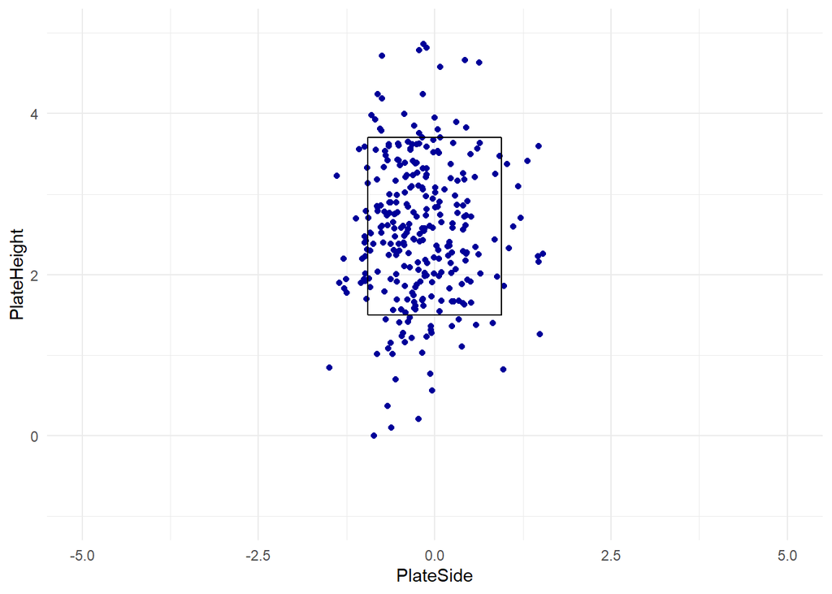

#### Best Whiff Probabilities

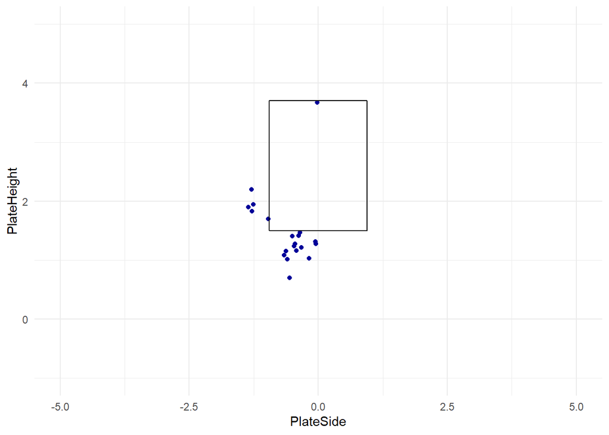

#### Worst Whiff Probabilities

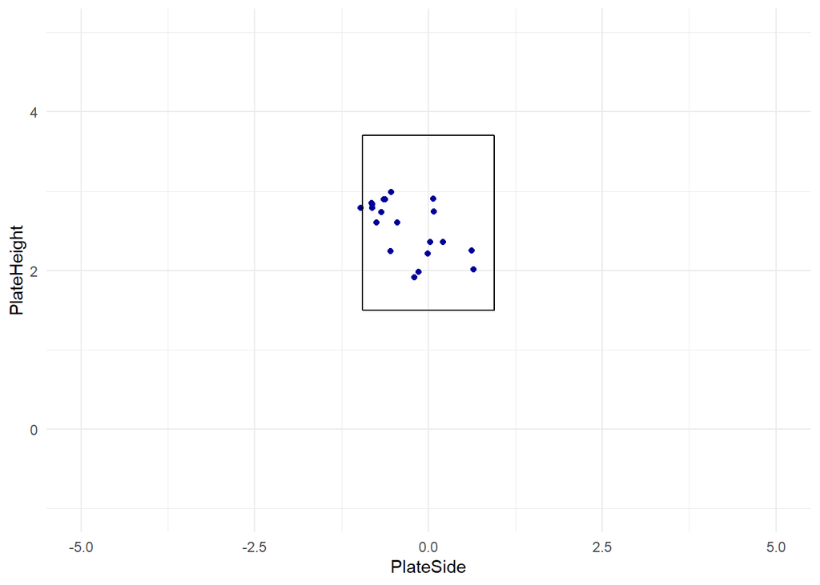

### Vs Right

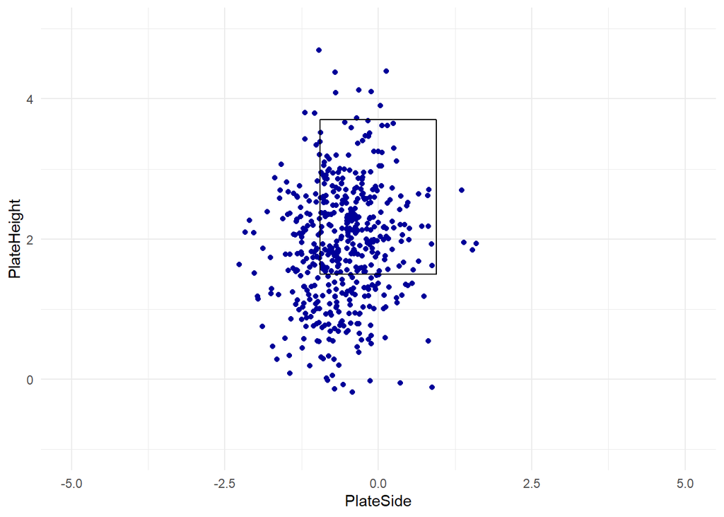

#### Best Whiff Probabilities

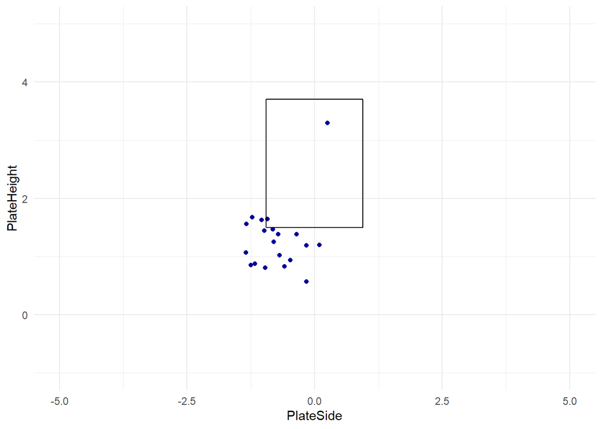

#### Worst Whiff Probabilities

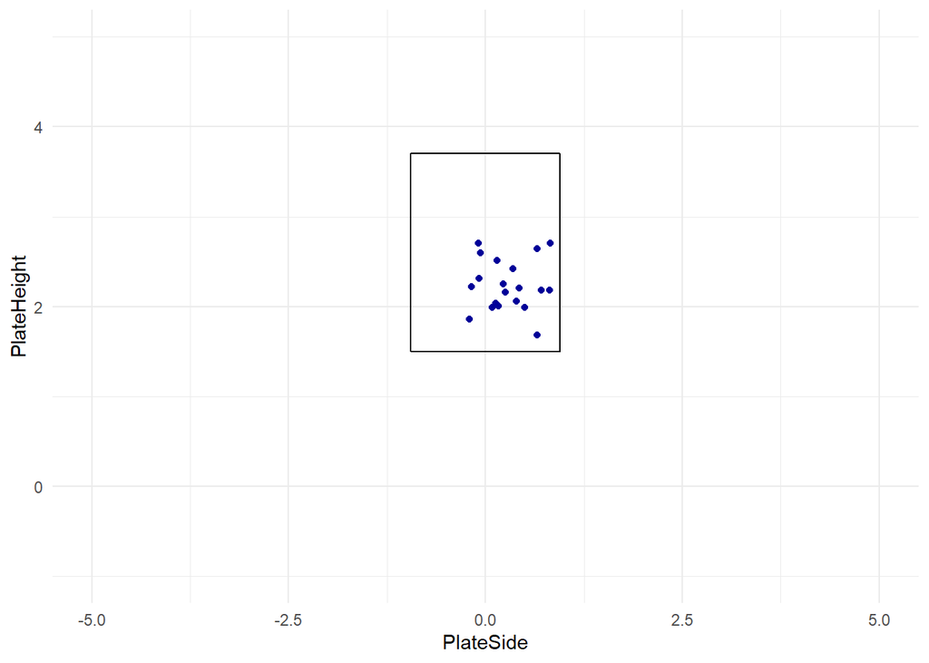

## Changeups

### Vs Left

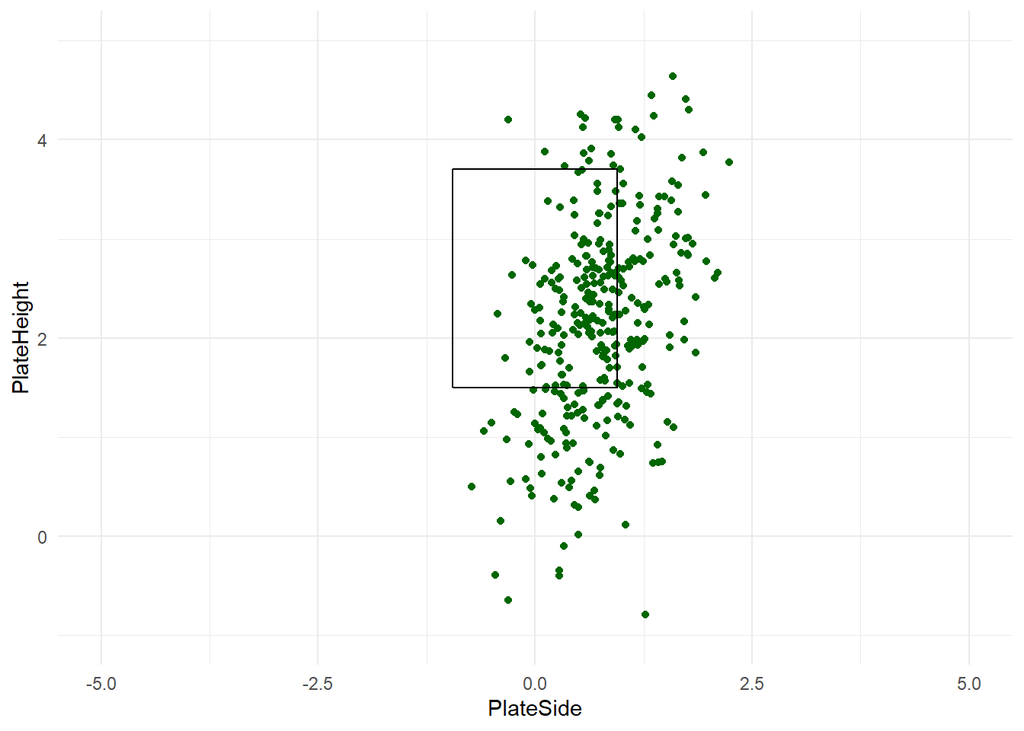

#### Best Whiff Probabilities

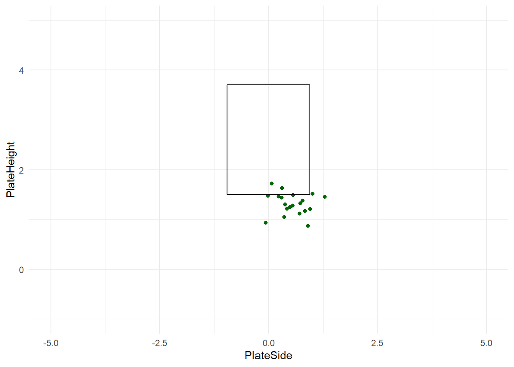

#### Worst Whiff Probabilities

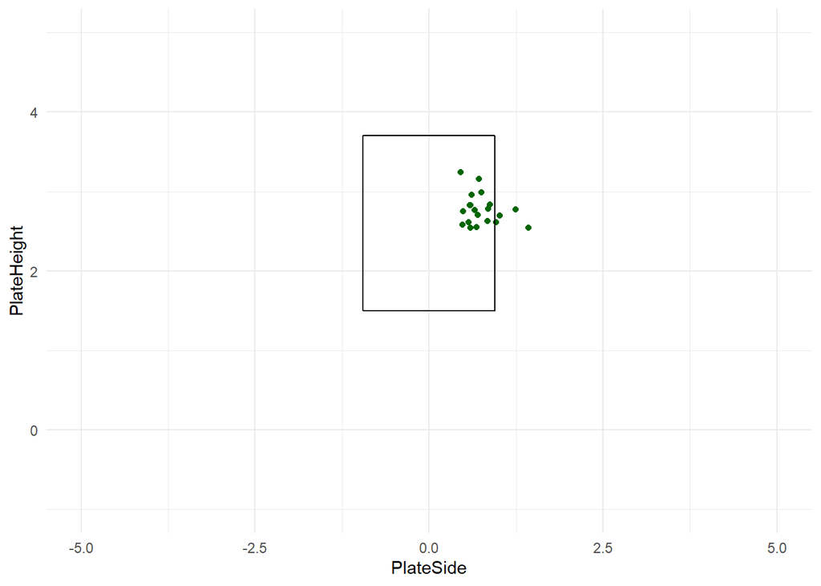

### Vs Right

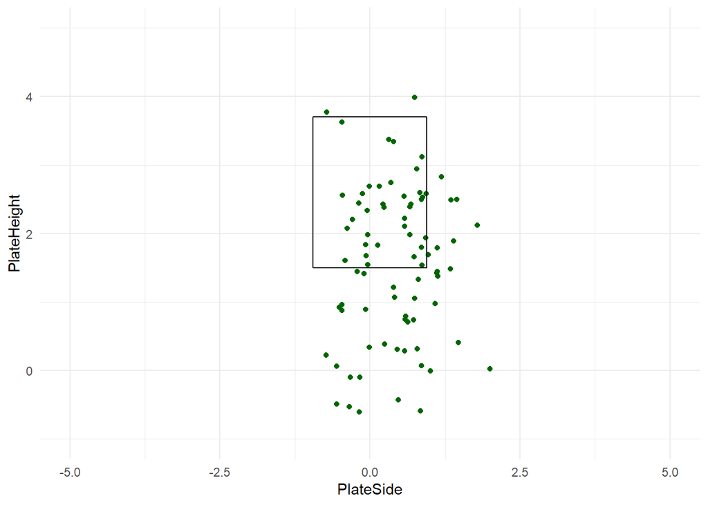

#### Best Whiff Probabilities

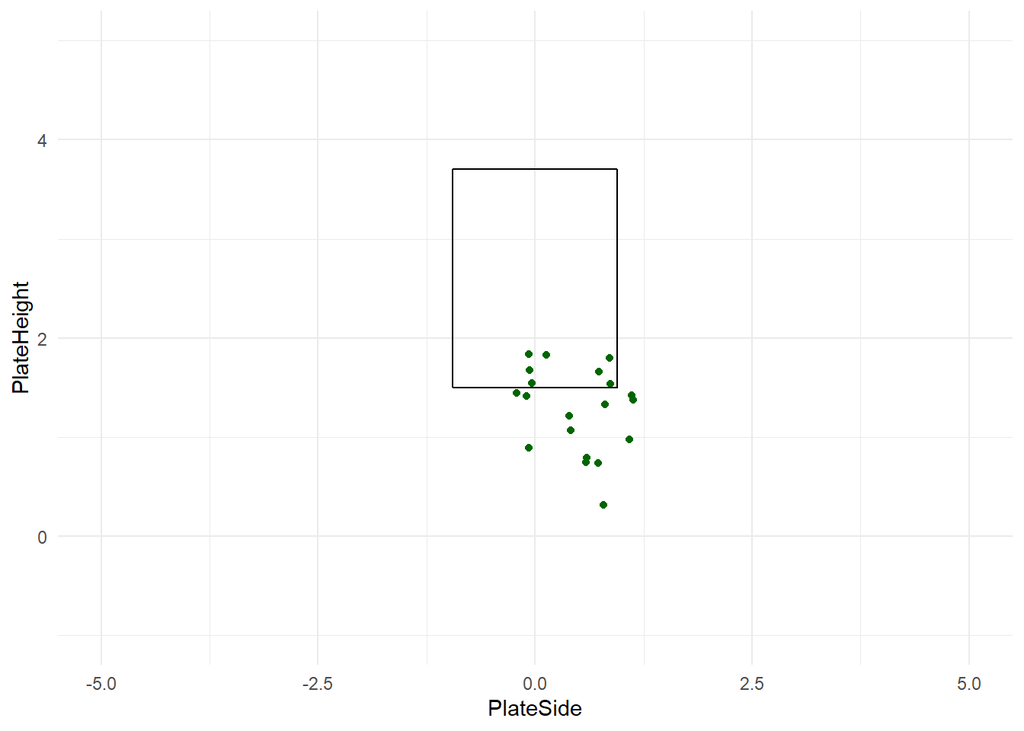

#### Worst Whiff Probabilities

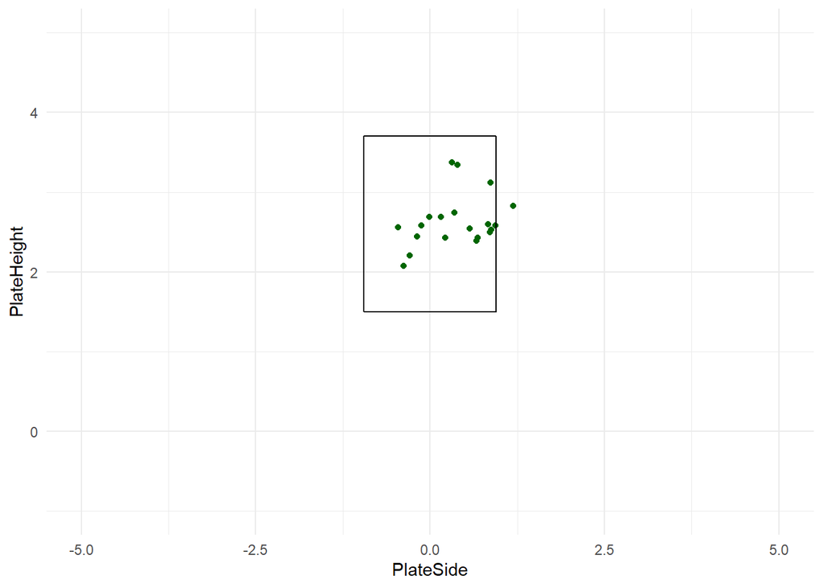

## Curveballs

### Vs Left

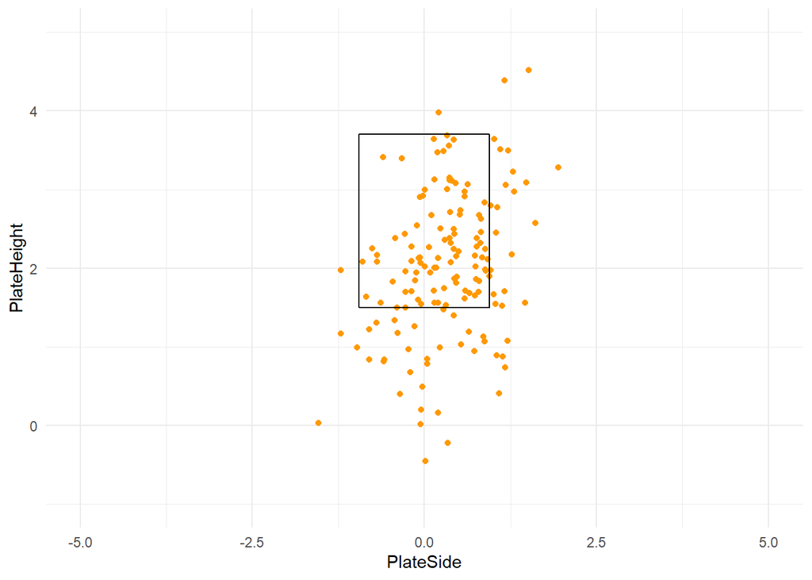

#### Best Whiff Probabilities

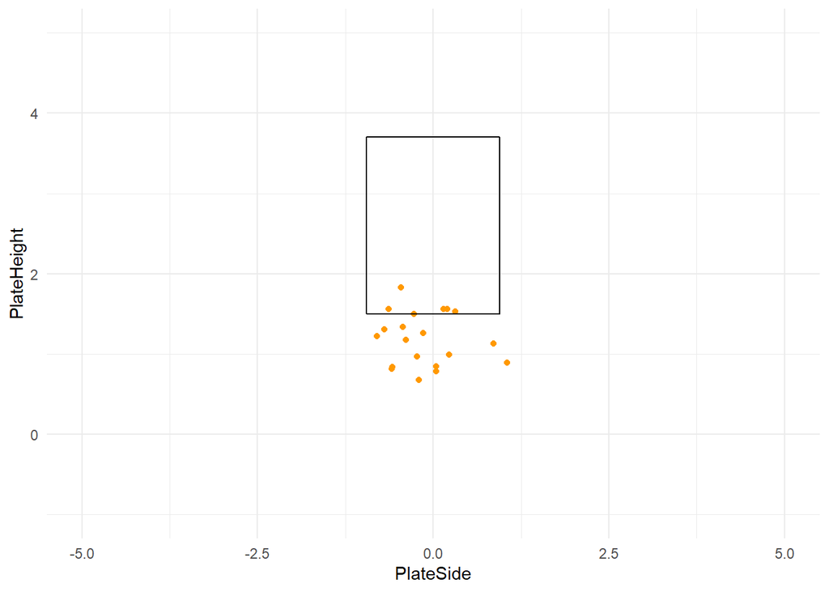

#### Worst Whiff Probabilities

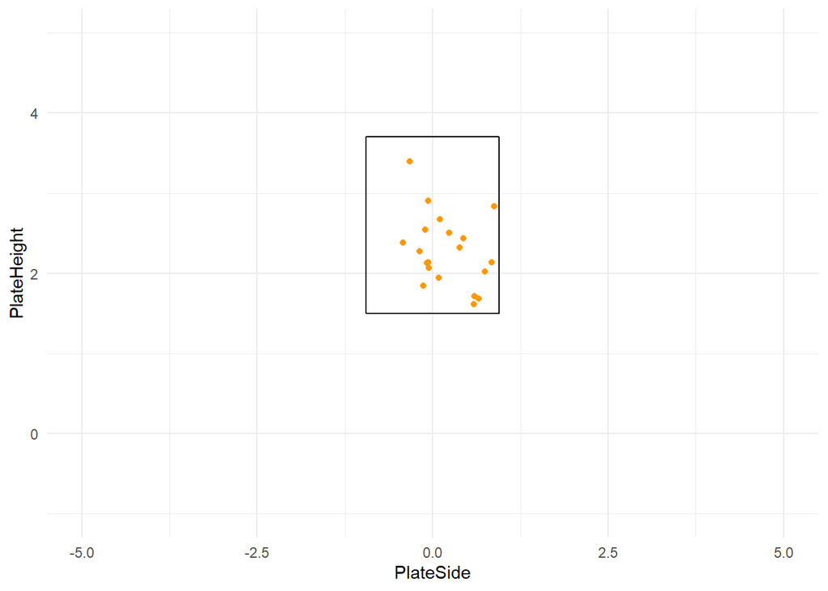

### Vs Right

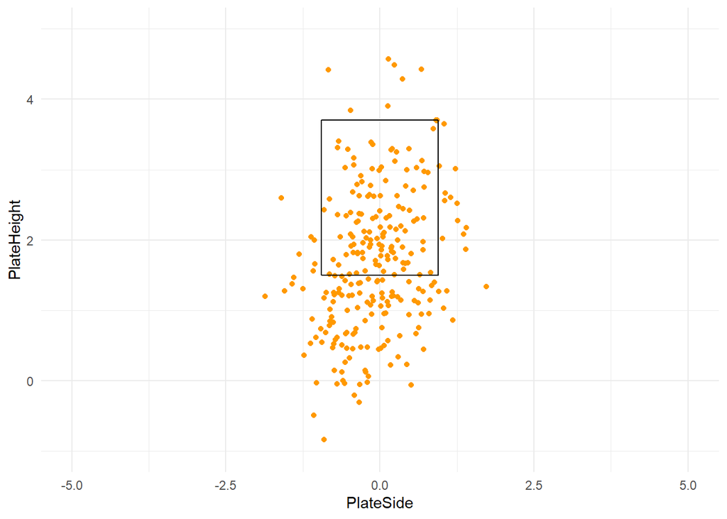

#### Best Whiff Probabilities

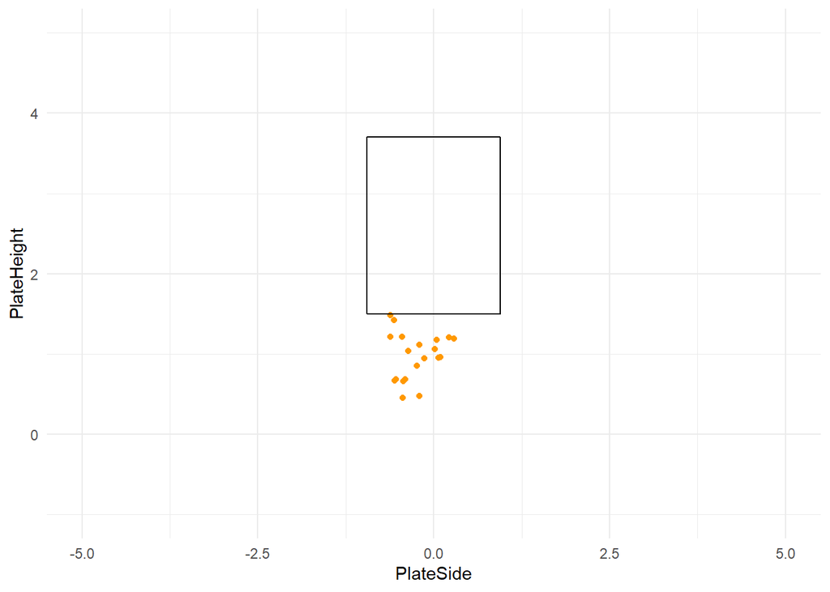

#### Worst Whiff Probabilities

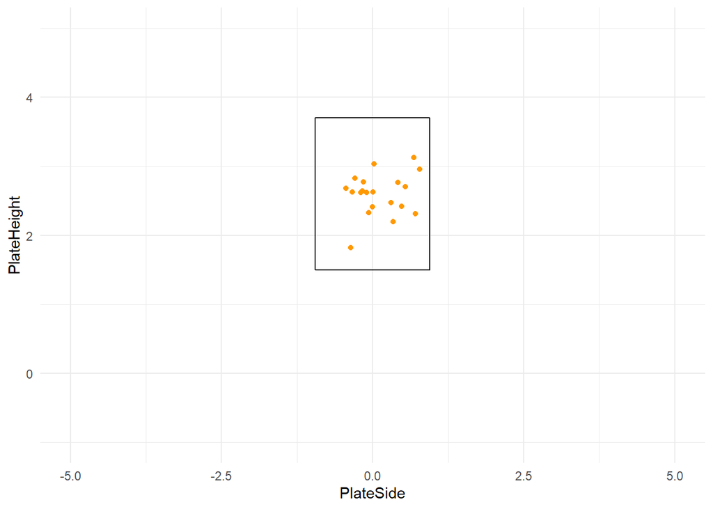

## Takeaways from this section

The biggest takeaway is that the fastballs are best in terms of whiff probability when up in the zone. Other than that, it is what you expect it to be with the good offspeed stuff being down and the bad being up. One other interesting thing is that changeups and cutters both do the best on the same side of the plate against righties and lefties.

# By Count

## Hitter’s Counts

### Vs Left Total

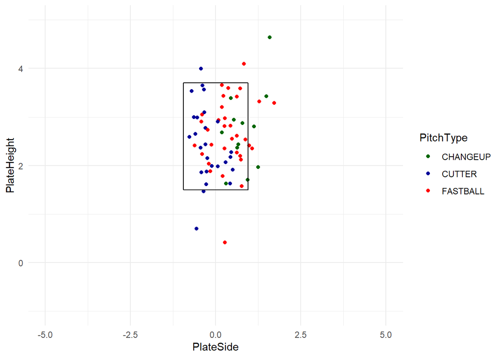

### Best Whiff Probabilities Vs Left

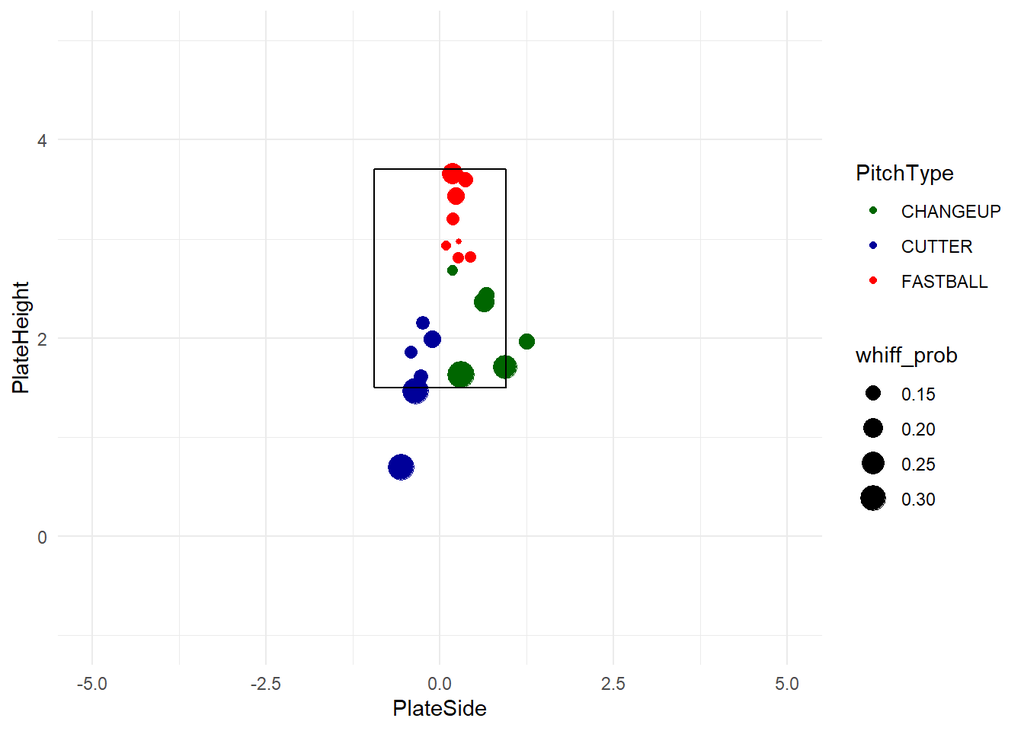

### Worst Whiff Probabilities Vs Left

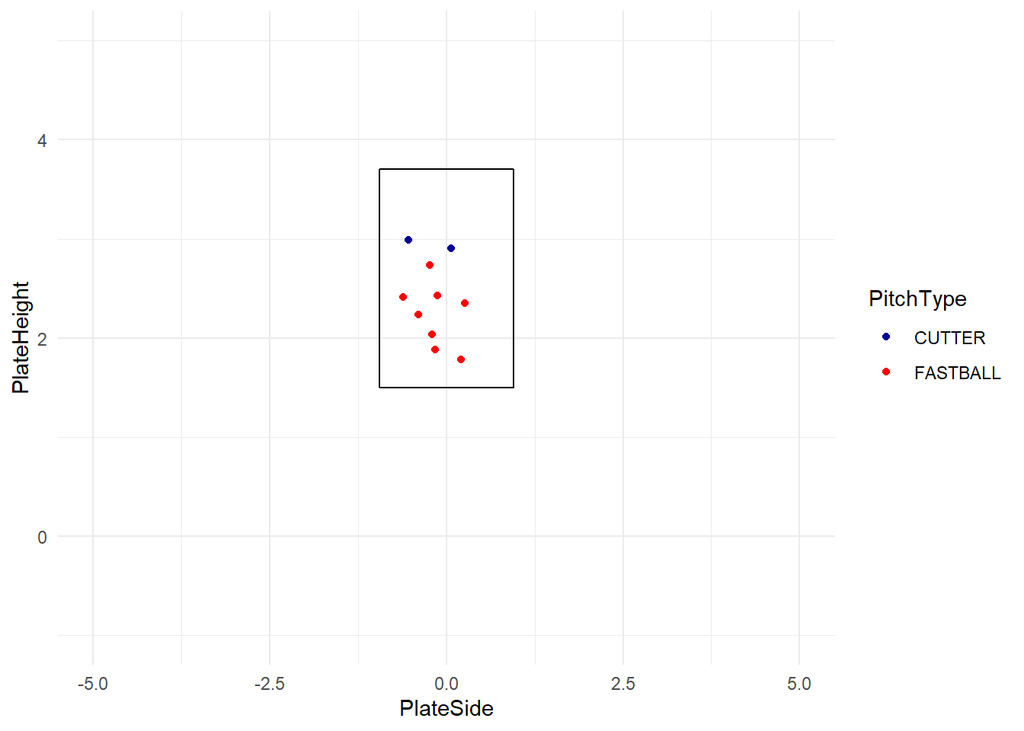

### Change in Whiff Probabilities Vs Left

| Change in Whiff Probabilty in Hitter’s Counts Vs Left Pitch Type | Change in Whiff Probabilty in Hitter’s Counts Vs Left Average Whiff Probability | Change in Whiff Probabilty in Hitter’s Counts Vs Left Average Whiff Probability in Hitter’s Count | Change in Whiff Probabilty in Hitter’s Counts Vs Left Change in Whiff Probability due to Count |
| --- | --- | --- | --- |
| CHANGEUP | 0.1478895 | 0.1289830 | -0.0189066 |
| CUTTER | 0.1249060 | 0.1000989 | -0.0248071 |
| FASTBALL | 0.0691044 | 0.0630171 | -0.0060873 |

### Vs Right Total

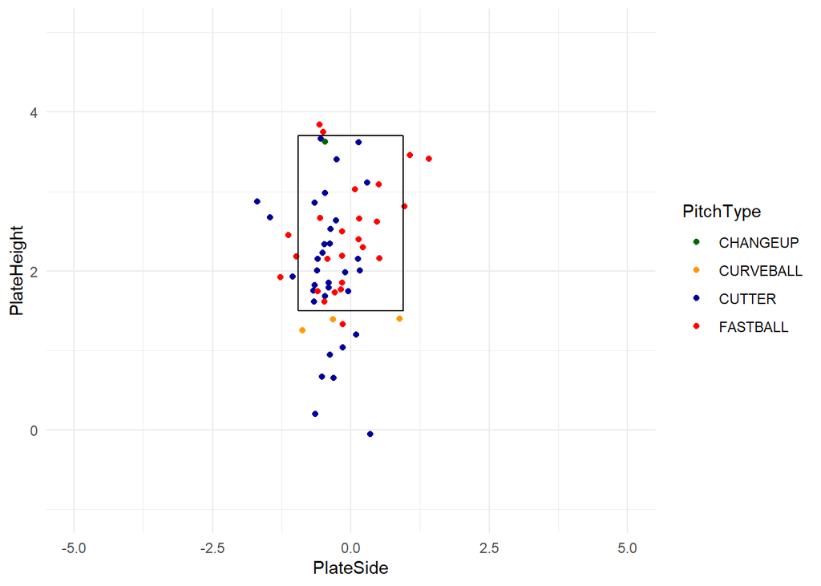

### Best Whiff Probabilities Vs Right

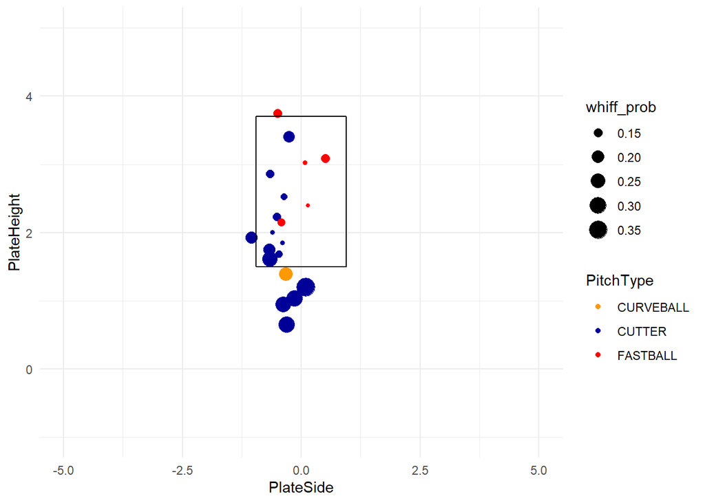

### Worst Whiff Probabilities Vs Right

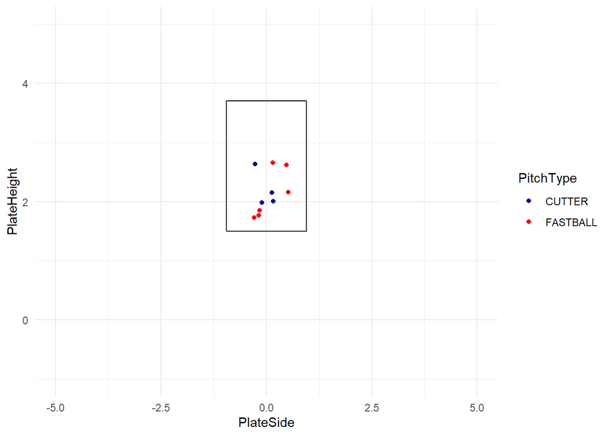

### Change in Whiff Probabilities Vs Right

| Change in Whiff Probabilty in Hitter’s Counts Vs Right Pitch Type | Change in Whiff Probabilty in Hitter’s Counts Vs Right Average Whiff Probability | Change in Whiff Probabilty in Hitter’s Counts Vs Right Average Whiff Probability in Hitter’s Count | Change in Whiff Probabilty in Hitter’s Counts Vs Right Change in Whiff Probability due to Count |
| --- | --- | --- | --- |
| CHANGEUP | 0.1717387 | 0.0170565 | -0.1546821 |
| CURVEBALL | 0.1207239 | 0.1259412 | 0.0052174 |
| CUTTER | 0.1471326 | 0.1326640 | -0.0144686 |
| FASTBALL | 0.0970859 | 0.0825249 | -0.0145610 |

## Pitcher’s Count

### Vs Left Total

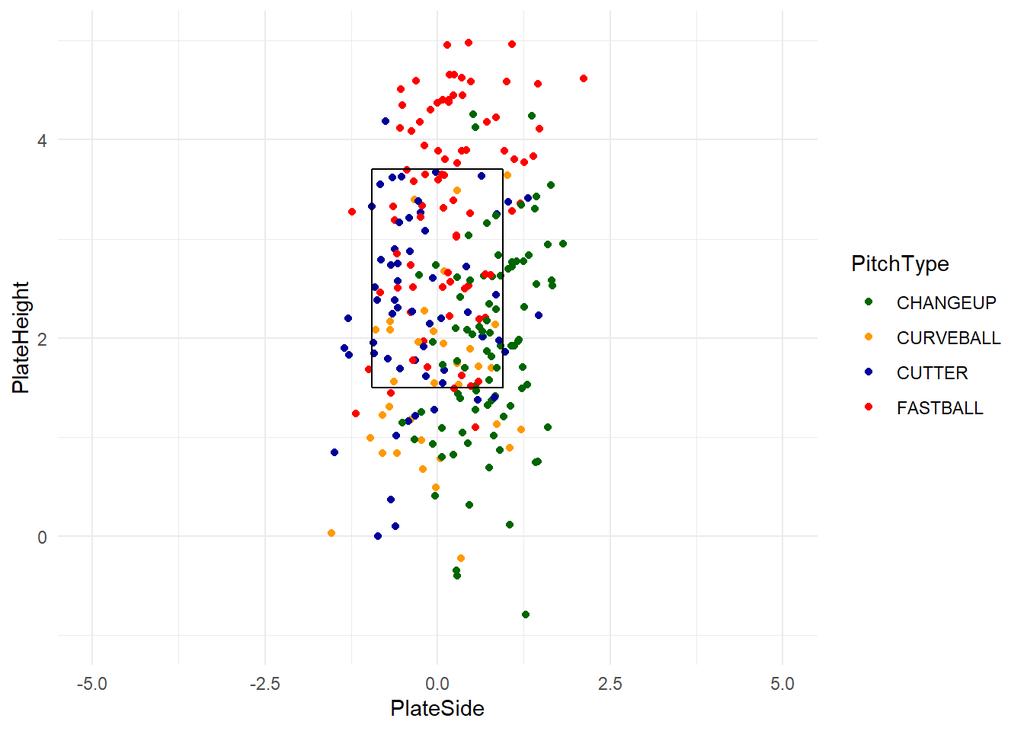

### Best Whiff Probabilities Vs Left

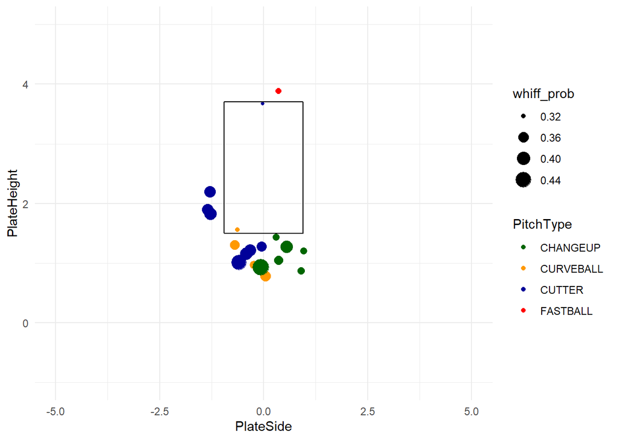